# **Evaluación de modelos para la predicción mensual de accidentes viales con Gravedad: Solo Daños**

Alexis A. Arenas Bustamante, Juan E. Arroyave Duque, William A. Jovel Tamayo, Manuela Londoño Ocampo.* Curso de Analítica Predictiva Universidad Nacional de Colombia Facultad de Minas Medellín

Septiembre de 2019

# 1 **Librerías Necesarias**

```r
library(dplyr) # data wrangling
library(ranger)
library(caret)
library(corrplot)
library(rsample)     # data splitting
library(rpart)       # performing regression trees
library(rpart.plot)  # plotting regression trees
library(ipred)       # bagging
require(MASS)
library(randomForest)
library(tidyverse)
library(ggpubr)
```

Se consideran tres modelos para la predicción mensual de los accidentes viales con solo daños: Regresión lineal, Árbol de regresión y Random Forest. A continuación se presenta la evaluación de cada uno:

# 2 **Dataset propuesto para el modelo mensual de accidentalidad vial : Solo daños**

|  | PERIODO | MES | SEMANA | FESTIVOS | SOLO_DANOS |
| --- | --- | --- | --- | --- | --- |
| 1 | 2014 | 1 | 1 | 1 | 34 |
| 2 | 2014 | 1 | 1 | 0 | 180 |
| 3 | 2014 | 1 | 2 | 0 | 294 |
| 4 | 2014 | 1 | 3 | 0 | 347 |
| 5 | 2014 | 1 | 4 | 0 | 378 |
| 6 | 2014 | 1 | 5 | 0 | 165 |

# 3 **Estadísticas Descriptivas**

## 3.1 **Summary del conjunto de datos**

```
##     PERIODO          MES             SEMANA         FESTIVOS
##  Min.   :2014   Min.   : 1.000   Min.   : 1.00   Min.   :0.0000
##  1st Qu.:2015   1st Qu.: 4.000   1st Qu.:14.00   1st Qu.:0.0000
##  Median :2016   Median : 7.000   Median :26.00   Median :0.0000
##  Mean   :2016   Mean   : 6.618   Mean   :26.93   Mean   :0.2136
##  3rd Qu.:2017   3rd Qu.:10.000   3rd Qu.:40.75   3rd Qu.:0.0000
##  Max.   :2018   Max.   :12.000   Max.   :53.00   Max.   :1.0000
##    SOLO_DANOS
##  Min.   :  6.0
##  1st Qu.: 62.0
##  Median :292.5
##  Mean   :242.2
##  3rd Qu.:373.0
##  Max.   :477.0
```

## 3.2 **Histograma de la variable dependiente**

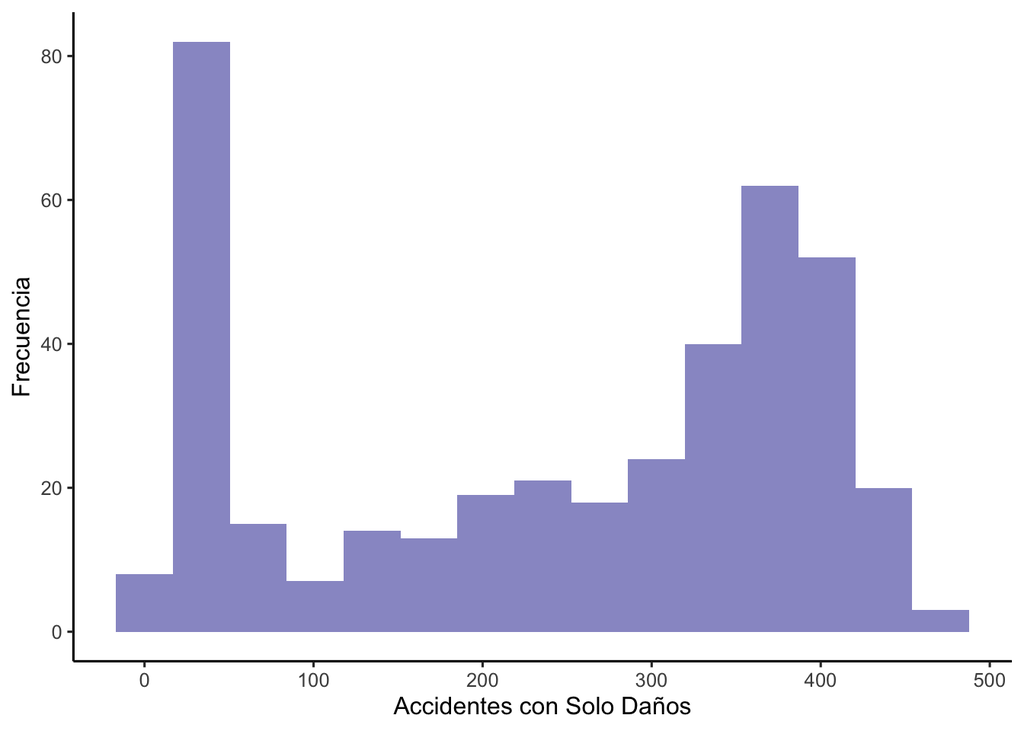

## 3.3 **Boxplots por mes**

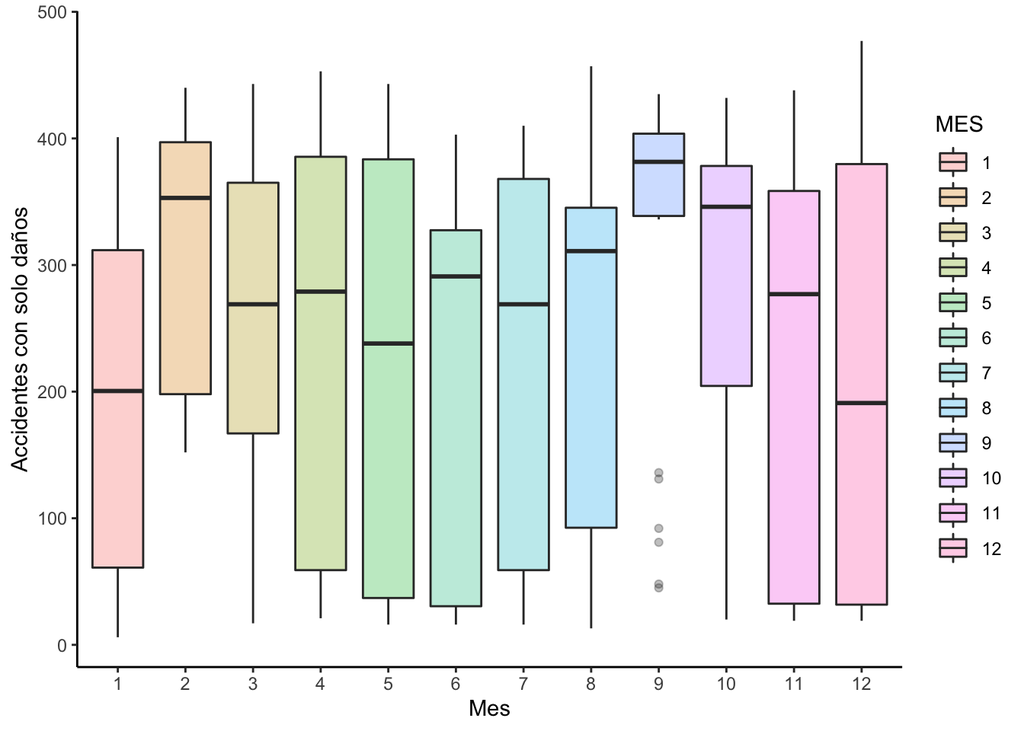

Se puede observar la presencia de ciertos valores atípicos por mes. Estos se trataran por medio de la imputación con mediana.

## 3.4 **Correlación entre variables consideradas**

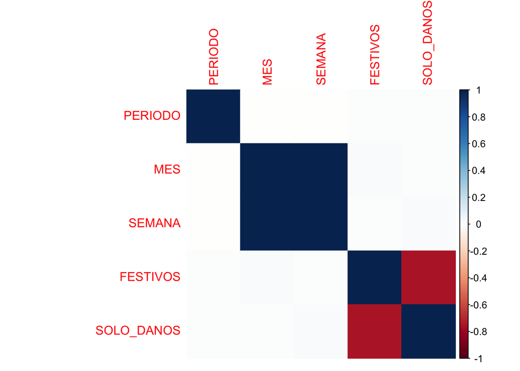

Se puede observar que la variable mas correlacionada con la cantidad de accidentes mensuales con solo daños es FESTIVOS. En cada uno de los modelos se identificará la importancia de las variables, de modo que solo se incluyan aquellas que tengan una influencia significativa sobre la variable dependiente. El periodo no hará parte de ningún modelo puesto que solo se usa para la partición de los datos en conjuntos de entrenamiento y validación.

## 3.5 **Evaluación y tratamiento de atípicos**

Se define una función para la identificación e imputación de los valores atípicos basado en el rango intercuartil. Se realiza la imputación con la mediana.

En la siguiente gráfica se pueden observar las distribuciones de los accidentes antes y después del tratamiento de datos atípicos

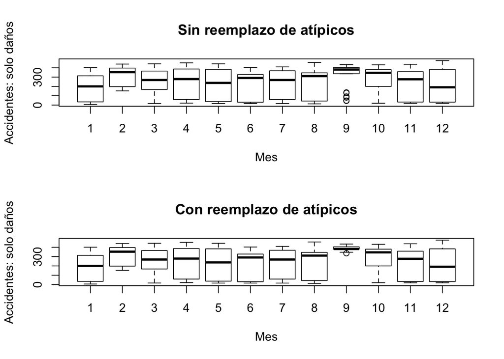

# 4 **Partición de los datos conjuntos de train y test**

Para la validación se usaran los datos de accidentes viales ocurridos en el año 2018.

*Datos de Train*: Se cuenta 318 observaciones para el entrenamiento de los modelos

```
## [1] 318   5
```

Datos de Test: Se cuenta con 80 observaciones para la validación de los modelos

```
## [1] 80  5
```

Una vez realizada la partición de los datos, se procede con la eliminación de la variable PERIODO en ambos datasets.

```r
soloD_train <- dplyr :: select(soloD_train, -PERIODO)
soloD_test <- dplyr :: select(soloD_test, -PERIODO)
```

# 5 **Modelo de predicción considerados**

## 5.1 **Regresión Lineal**

**Entrenamiento del modelo**

```r
# Variable como factor
soloD_train$SEMANA <- as.factor(soloD_train$SEMANA)
regresion_1 <- lm(SOLO_DANOS.R ~., data = soloD_train)
summary(regresion_1)
```

```
##
## Call:
## lm(formula = SOLO_DANOS.R ~ ., data = soloD_train)
##
## Residuals:
##      Min       1Q   Median       3Q      Max
## -154.010  -23.610   -1.553   20.736  121.130
##
## Coefficients:
##             Estimate Std. Error t value Pr(>|t|)
## (Intercept)  247.140     15.236  16.221  < 2e-16 ***
## MES2          53.250     29.737   1.791 0.074534 .
## MES3          83.750     42.054   1.991 0.047502 *
## MES4        -164.093     51.553  -3.183 0.001640 **
## MES5          56.922     57.595   0.988 0.323950
## MES6          16.451     62.964   0.261 0.794094
## MES7        -211.059     69.661  -3.030 0.002701 **
## MES8         -36.809     75.743  -0.486 0.627408
## MES9          85.941     81.371   1.056 0.291901
## MES10         96.691     93.978   1.029 0.304525
## MES11        108.034     97.800   1.105 0.270364
## MES12        -70.966    102.221  -0.694 0.488170
## SEMANA2       29.016     21.770   1.333 0.183790
## SEMANA3       95.110     25.967   3.663 0.000304 ***
## SEMANA4      112.860     25.967   4.346 2.01e-05 ***
## SEMANA5      -95.140     25.967  -3.664 0.000303 ***
## SEMANA6       81.610     39.478   2.067 0.039731 *
## SEMANA7      102.360     39.478   2.593 0.010073 *
## SEMANA8       71.610     39.478   1.814 0.070876 .
## SEMANA9     -124.890     39.478  -3.164 0.001749 **
## SEMANA10      65.610     49.425   1.327 0.185548
## SEMANA11      64.360     49.425   1.302 0.194037
## SEMANA12     -21.000     47.018  -0.447 0.655517
## SEMANA13     -26.380     47.808  -0.552 0.581579
## SEMANA14     255.159     56.812   4.491 1.08e-05 ***
## SEMANA15     257.797     56.301   4.579 7.34e-06 ***
## SEMANA16     234.963     56.301   4.173 4.13e-05 ***
## SEMANA17     327.703     57.595   5.690 3.51e-08 ***
## SEMANA18     -14.047     57.595  -0.244 0.807518
## SEMANA19      76.545     62.453   1.226 0.221479
```

[output cut: 26 more lines]

```
## SEMANA46     -32.659    100.035  -0.326 0.744332
## SEMANA47      34.326    101.196   0.339 0.734739
## SEMANA48     -68.674    101.196  -0.679 0.497996
## SEMANA49     165.716    104.361   1.588 0.113557
## SEMANA50     233.326    105.475   2.212 0.027850 *
## SEMANA51     273.326    105.475   2.591 0.010114 *
## SEMANA52     111.841    104.361   1.072 0.284890
## SEMANA53    -136.674    105.475  -1.296 0.196225
## FESTIVOS    -282.030      6.654 -42.385  < 2e-16 ***
## ---
## Signif. codes:  0 '***' 0.001 '**' 0.01 '*' 0.05 '.' 0.1 ' ' 1
##
## Residual standard error: 42.05 on 253 degrees of freedom
## Multiple R-squared:  0.9362, Adjusted R-squared:   0.92
## F-statistic: 57.99 on 64 and 253 DF,  p-value: < 2.2e-16
```

Las variables MES y SEMANA se incluyeron en el modelo de regresión lineal como factores. Algunas de las variables incluidad en el modelo no son significativas, pero según el summary se tiene un buen R-squared, que explica el 93.62 % de la accidentalidad mensual con gravedad de solo daños. De igual manera el valor P del estadístico F es significativo.

**Métricas de Bondad para regresión lineal**

| RMSE_Train | Rsquared_Train | RMSE_Test | Rsquared_Test |
| --- | --- | --- | --- |
| 37.51057 | 0.9361804 | 45.45824 | 0.9084536 |

**Ajuste de las predicciones vs valores reales**

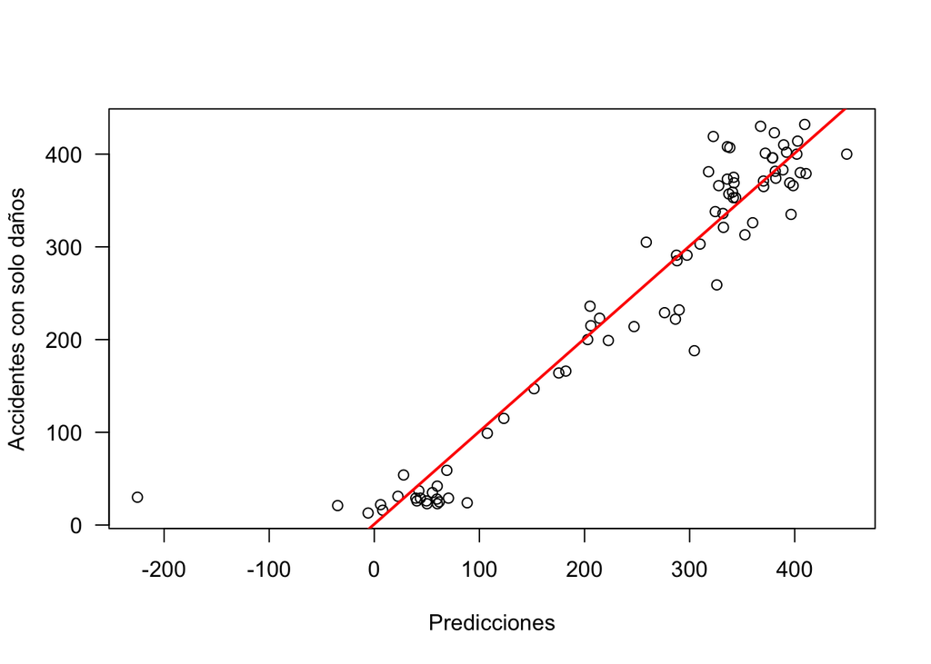

## 5.2 **Árbol Regresor**

**Entrenamiento del modelo**

Se toma el modelo mas simple para el árbol regresor, a partir de este se realizará una búsqueda tipo **grid search** para la definición de parámetros de restricción óptimos. Se crean dos funciones para extraer el mínimo error asociado con el valor óptimo de costo de complejidad (CP) de cada modelo y para el extraer el valor óptimo CP.

```r
set.seed(123)
dt_sd <- rpart(
  formula = SOLO_DANOS.R ~ .,
  data    = soloD_train,
  method  = "anova")
```

**Representación gráfica del árbol regresor sin tuning**

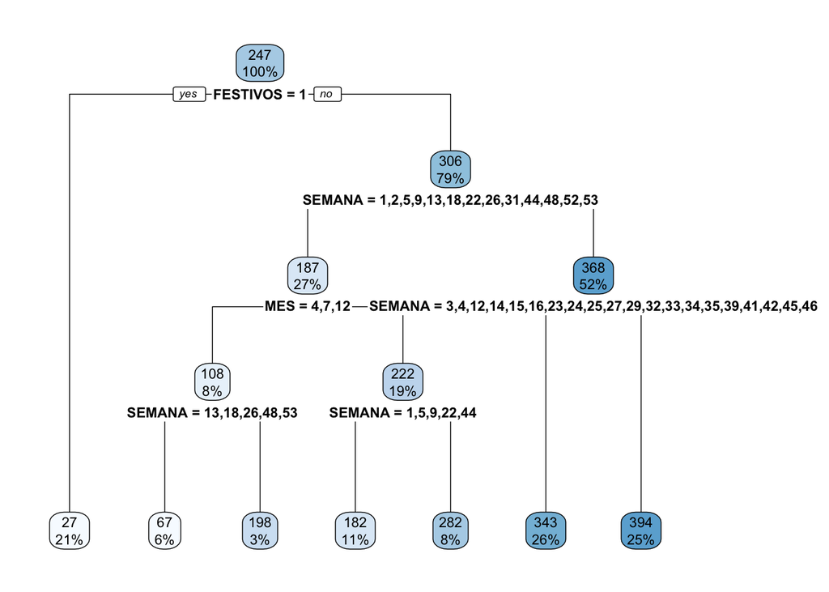

**Ajuste de parámetro de restricción para el árbol regresor**

Se realiza una búsqueda de los parámetros óptimos de minsplit y maxdepth para el árbol regresor:

En la siguiente gráfica se puede observar el numero optimo de nodos identificado por el modelo que reduce el error asociado. Este será el punto de partida para definir entre que valores puede variar el parámetro de profundidad del árbol. Vemos que el arbol optimo inicial tiene 6 divisiones y 7 nodos finales.

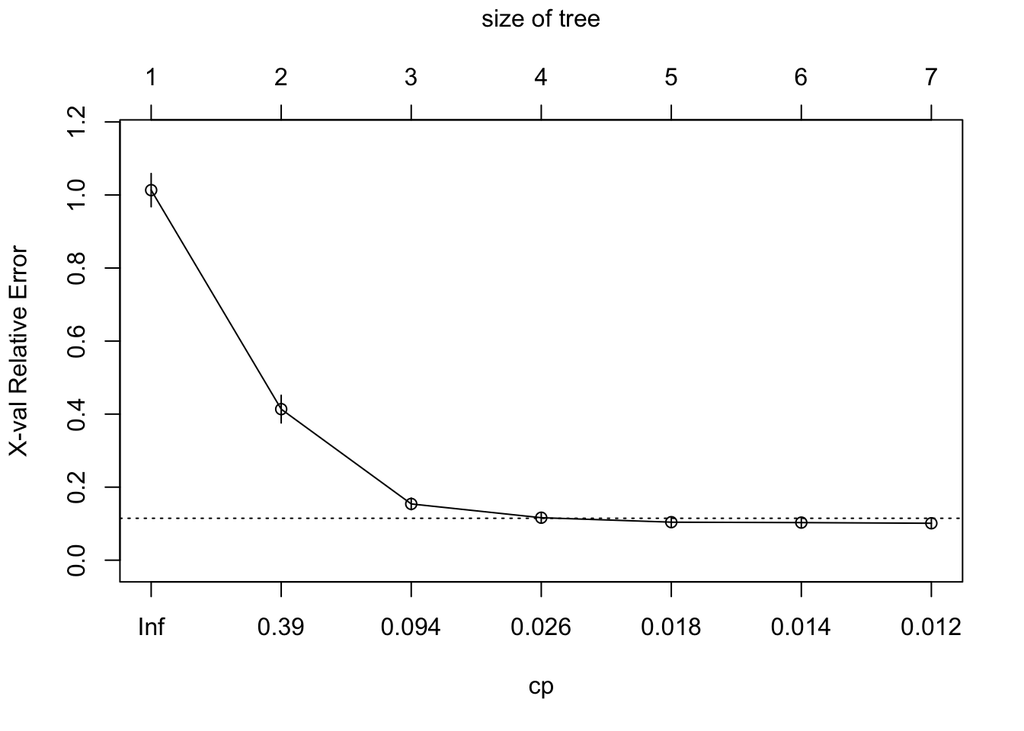

```r
plotcp(dt_sd)
```

```r
dt_sd2 <- rpart(
    formula = SOLO_DANOS.R ~ .,
    data    = soloD_train,
    method  = "anova",
    control = list(cp = 0, xval = 10)
)
```

[output not shown]

El siguiente código define una función grid para la búsqueda de diferentes combinaciones de minsplit y maxdepth. También las funciones que extraen el optimo cp y el mínimo error asociado.

```r
hyper_grid_sd <- expand.grid(
  minsplit = seq(5, 30, 1),
  maxdepth = seq(5, 8, 1))

models_sd <- list()

for (i in 1:nrow(hyper_grid_sd)) {

  # get minsplit, maxdepth values at row i
  minsplit <- hyper_grid_sd$minsplit[i]
  maxdepth <- hyper_grid_sd$maxdepth[i]

  # train a model and store in the list
  models_sd[[i]] <- rpart(
    formula = SOLO_DANOS.R ~ .,
    data    = soloD_train,
    method  = "anova",
    control = list(minsplit = minsplit, maxdepth = maxdepth)
    )
}

# function to get optimal cp
get_cp <- function(x) {
  min    <- which.min(x$cptable[, "xerror"])
  cp <- x$cptable[min, "CP"]
}

# function to get minimum error
get_min_error <- function(x) {
  min    <- which.min(x$cptable[, "xerror"])
  xerror <- x$cptable[min, "xerror"]
}
```

Agregaremos los resultados de la búsqueda a la grilla de hyper-parámetros y filtraremos los 5 valores con error mínimo.

```r
hyper_grid_sd %>%
  mutate(
    cp    = purrr::map_dbl(models_sd, get_cp),
    error = purrr::map_dbl(models_sd, get_min_error)
    ) %>%
  arrange(error) %>%
  top_n(-5, wt = error)
```

| minsplit | maxdepth | cp | error |
| --- | --- | --- | --- |
| 21 | 7 | 0.01000000 | 0.08454722 |
| 24 | 6 | 0.01000000 | 0.08536285 |
| 24 | 5 | 0.01000000 | 0.08641570 |
| 26 | 8 | 0.01351641 | 0.08798876 |
| 15 | 6 | 0.01000000 | 0.08920869 |

Vemos que el error se redujo a 0.084, lo cual indica mejores modelos en comparación con el modelo inicial. Se entrena el árbol regresor con las combinaciones que encabezan los resultados anteriores:

```r
optimal_tree_sd <- rpart(
    formula = SOLO_DANOS.R ~ .,
    data    = soloD_train,
    method  = "anova",
    control = list(minsplit = 21, maxdepth = 7, cp = 0.01)
    )
```

**Métricas de Bondad para el mejor árbol regresor**

```r
soloD_test$MES <- as.factor(soloD_test$MES)
soloD_test$SEMANA <- as.factor(soloD_test$SEMANA)


pred_dt_train = predict(optimal_tree_sd, newdata=soloD_train)
pred_dt_test = predict(optimal_tree_sd, newdata=soloD_test)

dt_sd_op1 <- data.frame(RMSE_Train = RMSE(pred_dt_train, soloD_train$SOLO_DANOS.R),
                    Rsquared_Train = R2(pred_dt_train, soloD_train$SOLO_DANOS.R),
                    RMSE_Test = RMSE(pred_dt_test, soloD_test$SOLO_DANOS.R),
                    Rsquared_Test = R2(pred_dt_test, soloD_test$SOLO_DANOS.R))


dt_sd_op1
```

| RMSE_Train | Rsquared_Train | RMSE_Test | Rsquared_Test |
| --- | --- | --- | --- |
| 37.96592 | 0.9346215 | 34.87412 | 0.9449379 |

Comparando las métricas consideradas tanto para el entrenamiento como para la validación del árbol óptimo, observamos que en ambos casos se obtuvo buenos R-squared, superiores al 90%. La variación entre los RMSE es del 8%, esta variación es baja y nos indica mejor ajuste en comparación con el modelo de regresión lineal.

**Mejor árbol regresor obtenido**

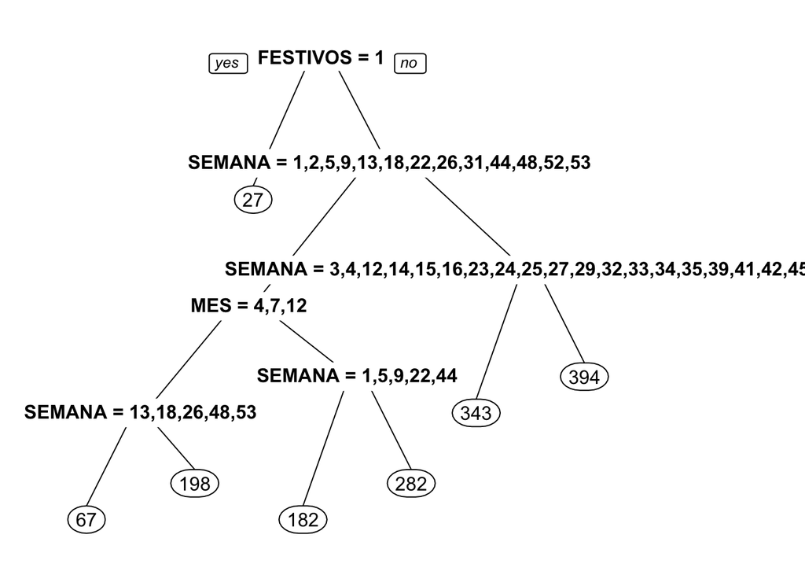

## 5.3 **Random Forest**

**Entrenamiento del modelo**

Se toma el modelo mas simple, a partir de este se realizará una búsqueda tipo **grid search** de los hiper parámetros óptimos con el uso de la librería Range. Se analizaron en total 144 modelos diferentes con variaciones en los parámetros de mtry, mínimo tamaño de muestras en el nodo, y tamaño de la muestra.

```r
set.seed(101)
rf_sd = randomForest(SOLO_DANOS.R ~ ., data = soloD_train)
rf_sd
```

```
##
## Call:
##  randomForest(formula = SOLO_DANOS.R ~ ., data = soloD_train)
##                Type of random forest: regression
##                      Number of trees: 500
## No. of variables tried at each split: 1
##
##           Mean of squared residuals: 3532.626
##                     % Var explained: 83.98
```

Inicialmente, observamos que la varianza explicada por el modelo es del 83,98 %.

**Este gráfico muestra el error vs. el número de árboles**

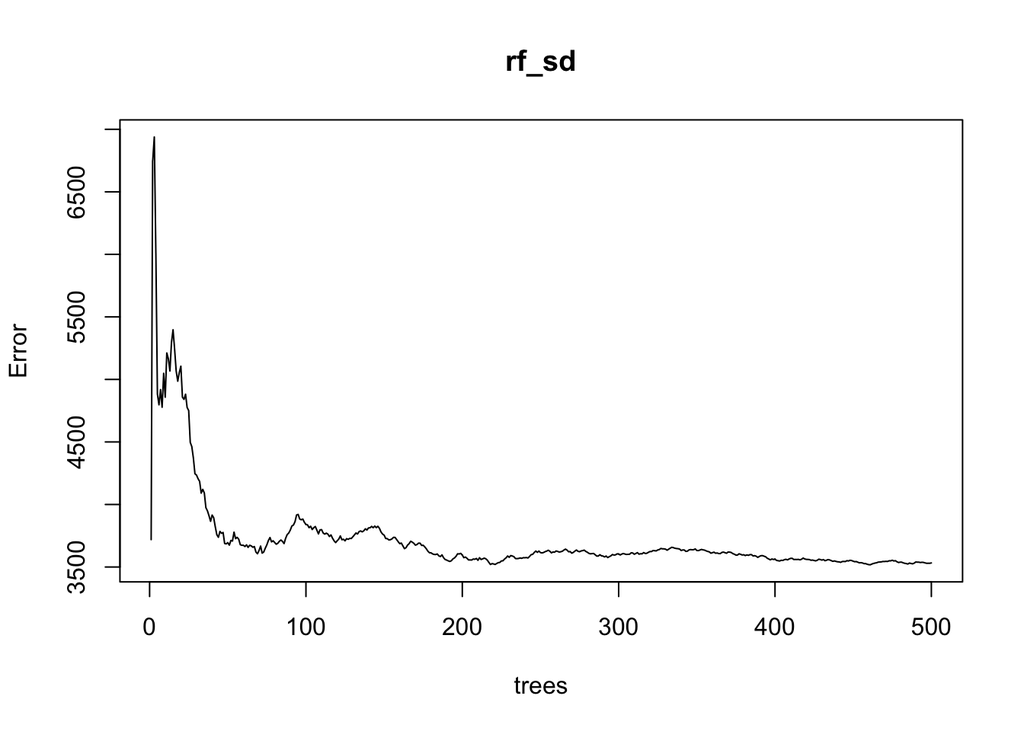

**Afinamiento del modelo Random Forest**

Se define la siguiente grilla de búsqueda:

```r
set.seed(101)

# hyperparameter grid search
hyper_grid_rf <- expand.grid(
  mtry       = seq(1, 3, by = 1),
  node_size  = seq(7, 30, by = 2),
  sampe_size = c(.55, .632, .70, .80),
  OOB_RMSE   = 0
)
# total number of combinations
#nrow(hyper_grid_rf)
```

Se utiliza la librería Ranger para la búsqueda de los mejores hyper parámetros:

```r
for(i in 1:nrow(hyper_grid_rf)) {

  # train model
  model <- ranger(
    formula         = SOLO_DANOS.R ~ .,
    data            = soloD_train,
    num.trees       = 500,
    mtry            = hyper_grid_rf$mtry[i],
    min.node.size   = hyper_grid_rf$node_size[i],
    sample.fraction = hyper_grid_rf$sampe_size[i],
    seed            = 101
  )

  # add OOB error to grid
  hyper_grid_rf$OOB_RMSE[i] <- sqrt(model$prediction.error)
}

hyper_grid_rf %>%
  dplyr::arrange(OOB_RMSE) %>%
  head(10)
```

|  | mtry | node_size | sampe_size | OOB_RMSE |
| --- | --- | --- | --- | --- |
| 1 | 3 | 7 | 0.800 | 45.36097 |
| 2 | 3 | 9 | 0.800 | 47.08719 |
| 3 | 3 | 7 | 0.700 | 47.21710 |
| 4 | 2 | 7 | 0.800 | 48.39689 |
| 5 | 3 | 7 | 0.632 | 48.97093 |
| 6 | 3 | 9 | 0.700 | 49.41053 |
| 7 | 3 | 11 | 0.800 | 49.47503 |
| 8 | 2 | 9 | 0.800 | 50.24759 |
| 9 | 2 | 7 | 0.700 | 50.71521 |
| 10 | 3 | 7 | 0.550 | 51.51064 |

Se ajusta el modelo con los mejores hyper parámetros obtenidos:

```r
set.seed(101)
mejorRandomforest <- randomForest(SOLO_DANOS.R ~., data = soloD_train, mtry = 3,
                                  nodesize = 7, ntree = 500, sampe_size= 0.8,
                                  importance = TRUE)

mejorRandomforest
```

```
##
## Call:
##  randomForest(formula = SOLO_DANOS.R ~ ., data = soloD_train,      mtry = 3, nodesize = 7, ntree = 500, sampe_size = 0.8, importance = TRUE)
##                Type of random forest: regression
##                      Number of trees: 500
## No. of variables tried at each split: 3
##
##           Mean of squared residuals: 1725.595
##                     % Var explained: 92.17
```

Con la función importance() se extrae la importancia de las variables.

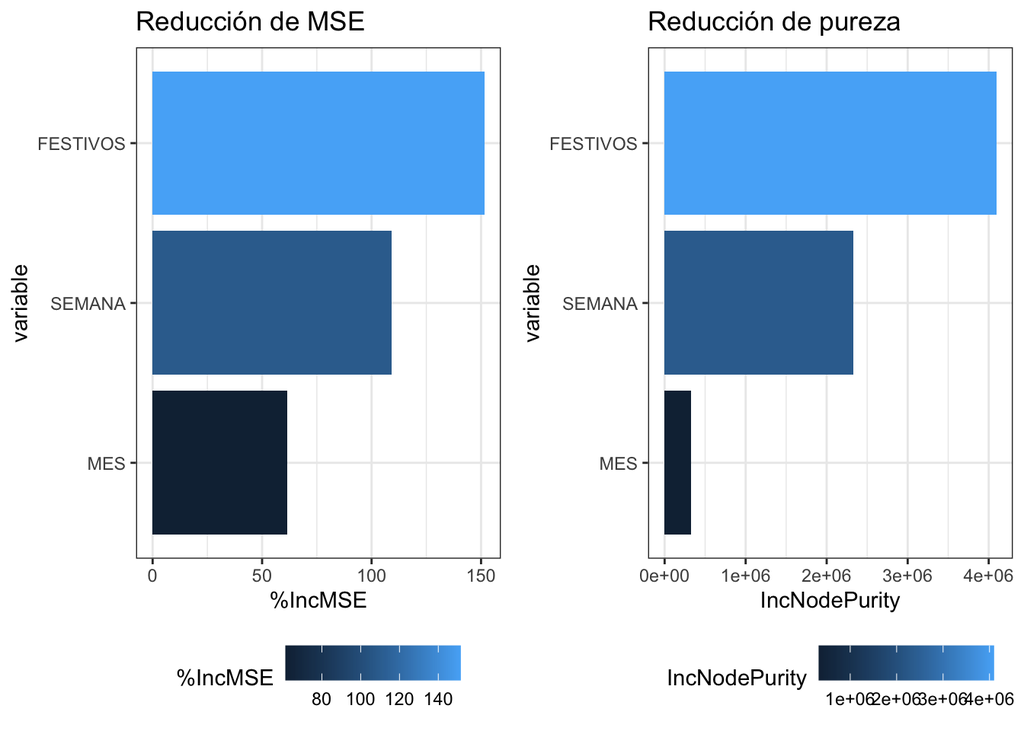

```r
importancia_pred <- as.data.frame(importance(mejorRandomforest, scale = TRUE))
importancia_pred <- rownames_to_column(importancia_pred, var = "variable")
p1 <- ggplot(data = importancia_pred, aes(x = reorder(variable, `%IncMSE`),
                                          y = `%IncMSE`,
                                          fill = `%IncMSE`)) +
    labs(x = "variable", title = "Reducción de MSE") +
    geom_col() +
    coord_flip() +
    theme_bw() +
    theme(legend.position = "bottom")

p2 <- ggplot(data = importancia_pred, aes(x = reorder(variable, IncNodePurity),
                                          y = IncNodePurity,
                                          fill = IncNodePurity)) +
    labs(x = "variable", title = "Reducción de pureza") +
    geom_col() +
    coord_flip() +
    theme_bw() +
    theme(legend.position = "bottom")
ggarrange(p1, p2)
```

**Métricas de bondad para modelo de Random Forest**

```r
pred_randomForest_t <- predict(mejorRandomforest, soloD_train)
pred_randomForest <- predict(mejorRandomforest, soloD_test)

dt_rf_1 <- data.frame(RMSE_Train = RMSE(pred_randomForest_t, soloD_train$SOLO_DANOS.R),
                    Rsquared_Train = R2(pred_randomForest_t, soloD_train$SOLO_DANOS.R),
                    RMSE_Test = RMSE(pred_randomForest, soloD_test$SOLO_DANOS.R),
                    Rsquared_Test = R2(pred_randomForest, soloD_test$SOLO_DANOS.R))


dt_rf_1
```

| RMSE_Train | Rsquared_Train | RMSE_Test | Rsquared_Test |
| --- | --- | --- | --- |
| 31.04968 | 0.9565553 | 31.23774 | 0.955922 |

Observamos que los R-squared para entrenamiento y validación son mas altos en comparación con los modelos de regresión lineal y Árbol regresor. El RMSE presenta una variación mínima, lo que hace que el modelo de RandomForest sea el mejor entre todos los modelos evaluados.